# Comparing `mgcv::bam` with `glmmLDTS` for the modeling and prediction of spotted seal haul-out behavior

Author

Affiliation

Josh M. London

Alaska Fisheries Science Center  
NOAA Fisheries

Published

September 3, 2023

**This is and evolving document**

Content, figures, and analysis within this document are evolving based on new things learned and feedback from others. This is an open learning exercise, not something to be cited or applied outside of this specific context.

## Inspiration & Objectives

The `glmmLDTS` package (Ver Hoef, London, and Boveng 2009) was developed and published over ten years ago and, at the time, provided a fast-computing solution for generalized linear mixed models with massive data sets and many repeated measures on subjects. While the package has general applicability, it was developed with behavioral observations from telemetry deployments on seals in mind (see example data in (Ver Hoef, London, and Boveng 2009) and analysis in (London et al. 2012)). In recent years, the `mgcv` package’s `bam()` model fitting function has emerged as a common solution for fitting similarly massive (if, even much more massive) data sets (Wood et al. 2017; Wood, Goude, and Shaw 2014; Li and Wood 2019). The `bam()` approach differs in that it fits a generalized additive model (GAM) and employs additional numerical methods designed for data sets containing upwards of several tens of thousands of data. The random effects are included as special penalized smooths. There is also support for AR1 structure in the model to account for temporal autocorrelation.

While `mgcv::bam()` relies on a low rank approximation it does use a full likelihood estimation. `glmmLDTS`, on the other hand, relies on quasi-likelihood but with a full rank approach. Additional simulation studies would be required to fully understand and throrouhgly compare the two (and, other frameworks such as `glmmTMB`, `gam`, `INLA` (first order Laplace approximation), `spaMM`, `spBayes`, and `spmodel` (second order Laplace approximation, see (Hoef et al. 2023)).

Here, the focus, is more on whether the speed of `mgcv::bam()` can be used as a tool for efficient model exploration and comparison in the sepecific case of spotted seal haul-out behavior from a large telemetry data set.

Initial testing and exploration of the `mgcv::bam()` approach suggests that models taking a few hours to fit with `glmmLDTS` can be fit in just a few seconds with `mgcv::bam()`. Thus, there’s keen interest in understanding whether the results of the fits are comparable and if `mgcv::bam()` might provide an astonishing improvement in computation time without sacrificing important statistical considerations and ecological insight.

Here, we compare speed, model performance, and predictions of `glmmLDTS` and `mgcv::bam()` for a data set of spotted seal haul-out observations from deployed telemetry devices. The primary aim of this model is to describe haul-out behavior during the critical periods of pupping, breeding, and molting and to also provide estimate of availability during aerial surveys such that counts of seals can provide estimates of population abundance. The data set consists of 114,852 from deployments on 105 individual spotted seals.

## Exploring `glmmLDTS` and Fit Results

The model specification below was used to specify the `glmmLDTS` model

```r
fit_spotted <- function(HO_spotted) {
  glmmLDTS(fixed.formula = dry ~ age_sex +
             sin1 + cos1 + sin2 + cos2 + sin3 + cos3 +
             poly(day, 4, raw=TRUE) +
             wind*temp2m + pressure + precip +
             age_sex:poly(day, 4, raw=TRUE),
           random.formula = dry ~ speno,
           data = HO_spotted,
           EstMeth = "REML",
           timecol = "time_vec",
           group.vec = "ar1_id")
}
```

As a general description of the model, *dry* is a binomial term that indicates whether a seal was out of the water for the majority of a given hour. A collection of fixed effects predictors are included such as *age and sex* class, weather conditions determined from climate reanalysis (e.g. *temperature (at 2m)*, *wind*, *precipitation*), linear, quadratic, cubic, and quatric effects of day-of-year to represent temporal changes in behavior, and time of day as a continuous formulation based on Fourier series (*sin1*, *cos1*, *sin2*, …) that provides a flexible model while preserving the inherent circularity needed for time-of-day effects (i.e., hour 0 should be equal to hour 24). It also represents hour-of-day with 6 parameters, which is a considerable reduction when compared to a 24-parameter variable. The random effect is *speno* (or seal identifier) which is further blocked into consecutive observations – the *ar1_id* specifies this grouping.

Table 1: Preview of fixed effects from the glmmLDTS model

|  | effect | levels | estimate | std.err | df | t.value | prob.t |
| --- | --- | --- | --- | --- | --- | --- | --- |
| 1 | intercept |  | -0.577619483 | 0.196772228 | 114822 | -2.935473 | 0.00333 |
| 2 | age_sex | ADULT.F | 0.000000000 | NA | NA | NA | NA |
| 3 | age_sex | ADULT.M | 0.379491785 | 0.277958097 | 114822 | 1.365284 | 0.17217 |
| 4 | age_sex | SUBADULT | -0.272680722 | 0.250518429 | 114822 | -1.088466 | 0.27639 |
| 5 | age_sex | YOUNG OF YEAR | 1.961605614 | 0.375635757 | 114822 | 5.222095 | 0.00000 |
| 6..35 |  |  |  |  |  |  |  |
| 36 | age_sex:day_4 | YOUNG OF YEAR, | 0.007596039 | 0.004649195 | 114822 | 1.633840 | 0.10230 |

## Exploring `mgcv::bam()` Fit & Results

The model specification below was used to specify the `mgcv::bam()` model

```r
m1 <- mgcv::bam(
  dry ~ age_sex + s(speno, bs = "re") +
    sin1 + cos1 + sin2 + cos2 + sin3 + cos3 +
    poly(day, 4, raw=TRUE) +
    wind*temp2m + pressure + precip +
    age_sex:poly(day, 4, raw=TRUE),
  data = spotted_model_data,
  family = binomial,
  discrete = TRUE)
```

The initial model specification was meant to match the previous `glmmLDTS` model. The `s(speno, bs = "re")` term is the smooth term for the random effect. All other predictors are the same. Note, the specification for `m1` here does **not** include any AR1 structure for temporal autocorrelation. To include this, we need to provide a value for $\rho$ (or *rho*). We can examine the autocorrelation within the model and use the lag-1 value for $\rho$ .

```r
lag1 <- acf(resid(m1), plot=FALSE)[1][[1]]
```

The value for lag-1 autocorrelation is 0.8255 which is rather high but not surprising. We can, now, update our model specification with a value for *rho* as well as the *A1.start* argument with specifies (TRUE/FALSE) the start point of each speno/block.

```r
m2 <- mgcv::bam(
  dry ~ age_sex + s(speno, bs = "re") +
    sin1 + cos1 + sin2 + cos2 + sin3 + cos3 +
    poly(day, 4, raw=TRUE) +
    wind*temp2m + pressure + precip +
    age_sex:poly(day, 4, raw=TRUE),
  data = spotted_model_data,
  family = binomial,
  AR.start = ar1_start,
  rho = lag1,
  discrete = TRUE)
```

Timing for the `mgcv::bam()` fit is approximately **4 seconds** on an Apple M1 Silicon laptop. Estimates of the fixed effects from the `mgcv::bam()` model are provided below in Table 2.

Table 2: Preview of fixed effects from the bam model

|  | term | estimate | std.error | statistic | p.value |
| --- | --- | --- | --- | --- | --- |
| 1 | (Intercept) | -0.594777463 | 0.196709850 | -3.023628 | 2.497631e-03 |
| 2 | age_sexADULT.M | 0.385801763 | 0.278617516 | 1.384700 | 1.661441e-01 |
| 3 | age_sexSUBADULT | -0.281249113 | 0.250613891 | -1.122241 | 2.617601e-01 |
| 4 | age_sexYOUNG OF YEAR | 1.950551281 | 0.372985192 | 5.229568 | 1.699070e-07 |
| 5 | sin1 | -0.045638470 | 0.020558838 | -2.219895 | 2.642586e-02 |
| 6..30 |  |  |  |  |  |
| 31 | age_sexYOUNG OF YEAR:poly(day, 4, raw = TRUE)4 | 0.007798545 | 0.004568144 | 1.707158 | 8.779265e-02 |

The estimates in Table 2 align quite well with those presented in Table 1. The same holds true for the estimates of standard error. This provides good indication that both approaches are interpreting the data in a very similar manner. There are, however, the `cos3` term is estimated as 0 in the `mgcv::bam()` model but has a non-zero estimates in the `glmmLDTS` output ( see Table 3 ). Understanding the nature of this is worth pursuing further at some point.

Table 3: Terms with zero estimate in the bam model

| term | estimate | std.error | statistic | p.value |
| --- | --- | --- | --- | --- |
| cos3 | 0 | 0 | NaN | NaN |

## Comparing Prediction Estimates and Confidence Intervals

So, it seems that both the original `glmmLDTS` approach and the `mgcv::bam()` approach can provide very similar fits with nearly identical coefficient estimates and standard errors. But, this is to be expected, I think, given that the *glmm* can be considered a special case of *gam* and the only smooth term included was for the random effect. The next area to explore is how the models might compare with respect to prediction estimates and the confidence intervals around those predictions.

For this prediction exercise, we’ll want to create a new data frame that includes all of the values we’d like to predict at. For this particular model, it’s a rather complex exercise and, thus, the complex function below (feel free to unfold the code block if interested).

```r
create_newdata <- function(data, age_sex) {
  df_list <- vector(mode = "list", length = length({{age_sex}} ))

  for (a_s in {{age_sex}}) {
    range_yday <- data %>% filter(age_sex == a_s ) %>%
      summarize(start_day = min(yday),
                end_day = max(yday))
    start_day <- range_yday$start_day
    end_day <- range_yday$end_day
    n_days = (end_day - start_day) + 1

    # for wx covariates we'll use a gam to get values by
    # day/hour since wx is likely to vary w/in day over the season

    gam.baro <-
      gam(pressure ~ s(yday),
          data = data,
          method = "REML")
    gam.temp <-
      gam(temp2m ~ s(yday) + s(as.numeric(solar_hour)),
          data = data,
          method = "REML")
    gam.wind <-
      gam(wind ~ s(yday) + s(as.numeric(solar_hour)),
          data = data,
          method = "REML")
    gam.precip <-
      gam(precip ~ s(yday),
          data = data,
          method = "REML")

    wx_new_data <- data.frame(
      solar_hour = rep(0:23, each = n_days),
      yday = rep(start_day:end_day, times = 24)
    )

    temp_pred <- predict(gam.temp, newdata = wx_new_data)
    wind_pred <- predict(gam.wind, newdata = wx_new_data)
    baro_pred <- predict(gam.baro, newdata = wx_new_data)
    precip_pred <- predict(gam.precip, newdata = wx_new_data)

    df <- data.frame(
      age_sex = a_s,
      solar_hour = rep(0:23, each = n_days),
      yday = rep(start_day:end_day, times = 24),
      northing = mean(data$northing),
      temp2m = temp_pred,
      wind = wind_pred,
      pressure = baro_pred,
      precip = precip_pred
    ) %>%
      mutate(
        sin1 = sin(pi * solar_hour / 12),
        cos1 = cos(pi * solar_hour / 12),
        sin2 = sin(pi * solar_hour / 6),
        cos2 = cos(pi * solar_hour / 6),
        sin3 = sin(pi * solar_hour / 4),
        cos3 = sin(pi * solar_hour / 4),
      ) %>%
      mutate(day = (yday - 120) / 10,
             day_2 = day^2,
             day_3 = day^3,
             day_4 = day^4)
    df_list[[a_s]] <- df
  }
  if(length({{age_sex}}) > 1) {
    df_out <- bind_rows(df_list) %>%
      mutate(age_sex = forcats::fct_relevel(
        age_sex,c("ADULT.F","ADULT.M","SUBADULT","YOUNG OF YEAR"))
      )
  } else {
    df_out <- bind_rows(df_list)
  }
}

spotted_newdata <- create_newdata(
  data = spotted_fit_glmm$dataset,
  age_sex = levels(spotted_fit_glmm$dataset$age_sex)
  )
```

### Predicting from the `glmmLDTS` model

Now, we need a function to predict from the `glmmLDTS` model. This isn’t an included function within the package so we’ll create our own.

```r
predict.glmmLDTS <- function(glmmLDTS_model, newdata,
                             type = "response") {
# create the model matrix
  spotted_mm <- model.matrix(glmmLDTS_model$fixed.formula[-2],
                            data = newdata)

  #clean up extra intercept and get coef
  fit_coef <- glmmLDTS_model$fixed.effects %>%
    filter(!is.na(std.err)) %>%
    pull(estimate)

  predicts <-
    tibble(logit_fits = as.vector(spotted_mm %*% fit_coef)) %>%
    mutate(logit_fits_se = sqrt(diag(
             spotted_mm %*% glmmLDTS_model$covb %*% t(spotted_mm)
             )),
           logit_fits_lo95 = logit_fits - 1.96*logit_fits_se,
           logit_fits_up95 = logit_fits + 1.96*logit_fits_se,
           ho_prob = plogis(spotted_mm %*% fit_coef),
           lower95 = plogis(logit_fits_lo95),
           upper95 = plogis(logit_fits_up95)
    )
  return(predicts)
}

spotted_newdata <- spotted_newdata %>%
  dplyr::bind_cols(
    predict.glmmLDTS(spotted_fit_glmm, spotted_newdata)
    )
```

### Predicting from the `mgcv::bam()` model

The `mgcv` package includes a `predict()` function for us, so we can proceed directly to prediction using our `spotted_newdata` and bind the results. The `predict.bam()` function requires a column for `speno` even though we are excluding the random effect (`s(speno)`) from the model prediction. As with the `glmmLDTS` prediction exercise, we’ll specify `type = "link"` and calculate our confidence intervals directly.

```r
spenos <- unique(spotted_model_data$speno) %>%
  as.character()

spotted_newdata <- spotted_newdata %>%
  mutate(speno = sample(spenos,1))

spotted_newdata <- spotted_newdata %>%
  bind_cols(
    predict(
      m2,
      spotted_newdata,
      type = "link",
      se.fit = TRUE,
      exclude = "s(speno)"
    ) %>%
      as_tibble()
  ) %>%
  rename(fit_bam = fit, se_bam = se.fit) %>%
  mutate(
    logit_bam_lo95 = fit_bam - 1.96 * se_bam,
    logit_bam_up95 = fit_bam + 1.96 * se_bam,
    ho_prob_bam = plogis(fit_bam),
    lower95_bam = plogis(logit_bam_lo95),
    upper95_bam = plogis(logit_bam_up95)
  )
```

Now, with predictions from both model approaches in hand, we can visualize the comparison of predictions and associated standard errors (Figure 1).

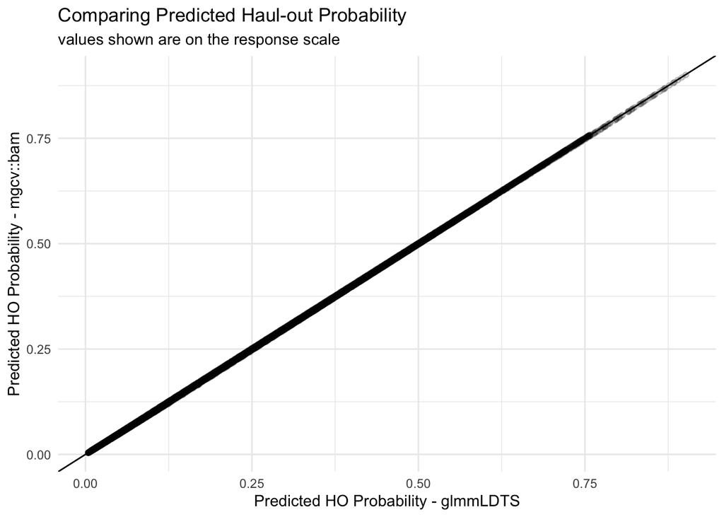

Figure 1: XY plot comparing the predicted haul-out probability (response scale) for the same data between the `glmmLDTS` model fit and the `mgcv::bam()` model fit

```r
ggplot(data = spotted_newdata) +
  geom_point(aes(x = ho_prob, y = ho_prob_bam),
             alpha = 0.1) +
  geom_abline(slope = 1, intercept = 0) +
  coord_cartesian() +
  xlab("Predicted HO Probability - glmmLDTS") +
  ylab("Predicted HO Probability - mgcv::bam") +
  ggtitle("Comparing Predicted Haul-out Probability",
          subtitle = "values shown are on the response scale") +
  theme_minimal() + theme(legend.position = "none")
```

This looks great!

Now, let’s visualize the predictions with a heat map (Figure 2) that depicts haul-out probability changes over the season and hour of day for each of our age and sex classes.

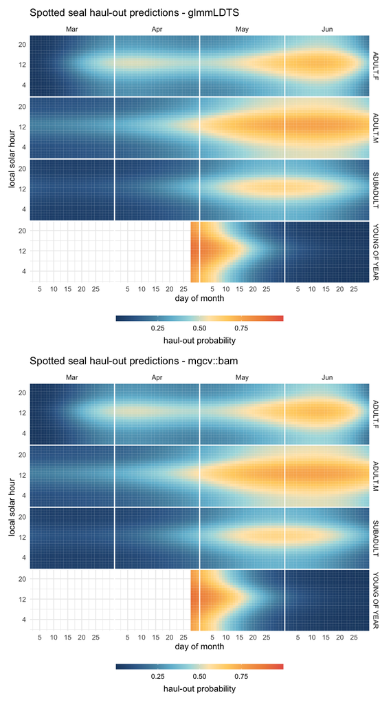

Figure 2: Heat maps showing the predicted haul-out probability (response scale) variability over the season and within day for the same data between the `glmmLDTS` model fit and the `mgcv::bam()` model fit

```r
plot_df <- spotted_newdata %>%
  mutate(date = lubridate::as_date(yday, origin = "2015-01-01"),
         month = lubridate::month(date,label=TRUE),
         day = lubridate::day(date)) %>%
  filter(!month %in% c("Jul","Aug"))

p1 <- ggplot(plot_df, aes(day, solar_hour, fill = ho_prob)) +
  geom_tile(color = "white", linewidth = 0) +
  scale_fill_gradientn(
    colors = rev(met.brewer("Hiroshige")),
    name = "haul-out probability",
    aesthetics = "fill",
    limits = c(0, 1),
    breaks = c(0.25, 0.50, 0.75),
    guide = guide_colorbar(
      title.position = "bottom",
      barwidth = 15,
      barheight = 0.5,
      title.hjust = 0.5
    )
  )

p1 <- p1 + facet_grid(age_sex~month, scales = "free_x")
p1 <- p1 + scale_x_continuous(breaks = c(5,10,15,20,25)) +
  scale_y_continuous(breaks = c(4,12,20)) +
  coord_cartesian(expand=FALSE)
p1 <- p1 + theme_minimal() +
  theme(panel.spacing = unit(0.1, "lines")) +
  theme(legend.position = "bottom") +
  theme(strip.background = element_rect(colour="white")) +
  theme(axis.ticks=element_blank()) +
  xlab("day of month") + ylab("local solar hour") +
  ggtitle("Spotted seal haul-out predictions - glmmLDTS")


p2 <- ggplot(plot_df, aes(day, solar_hour, fill = ho_prob_bam)) +
  geom_tile(color = "white", linewidth = 0) +
  scale_fill_gradientn(
    colors = rev(met.brewer("Hiroshige")),
    name = "haul-out probability",
    aesthetics = "fill",
    limits = c(0, 1),
    breaks = c(0.25, 0.50, 0.75),
    guide = guide_colorbar(
      title.position = "bottom",
      barwidth = 15,
      barheight = 0.5,
      title.hjust = 0.5
    )
  )
p2 <- p2 + facet_grid(age_sex~month, scales = "free_x")
p2 <- p2 + scale_x_continuous(breaks = c(5,10,15,20,25)) +
  scale_y_continuous(breaks = c(4,12,20)) +
  coord_cartesian(expand=FALSE)
p2 <- p2 + theme_minimal() +
  theme(panel.spacing = unit(0.1, "lines")) +
  theme(legend.position = "bottom") +
  theme(strip.background = element_rect(colour="white")) +
  theme(axis.ticks=element_blank()) +
  xlab("day of month") + ylab("local solar hour") +
  ggtitle("Spotted seal haul-out predictions - mgcv::bam")

p1/p2
```

That looks great, too!

So far, we’ve shown that the model estimates, associated standard errors, and prediction values for haul-out probability are very similar between the `glmmLDTS` and `mgcv::bam()` approach. The final comparison to evaluate is the prediction standard errors. We’ll start with an XY plot similar to what we did for the prediction estimates.

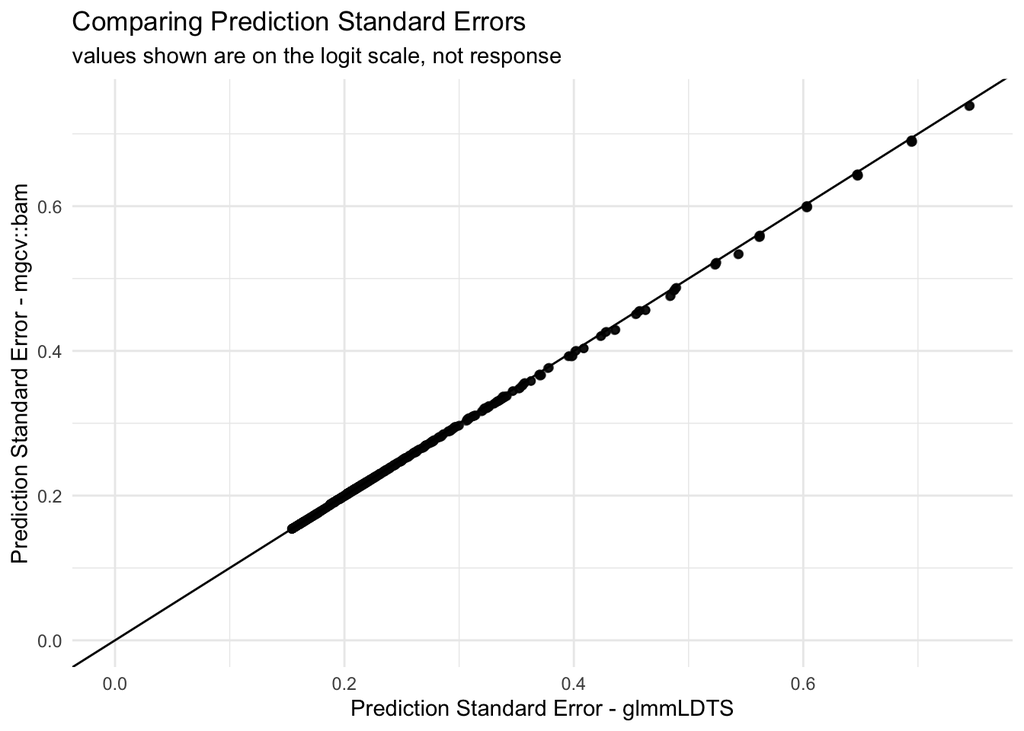

XY plot comparing the predicted standard errors (link scale) for the same data between the `glmmLDTS` model fit and the `mgcv::bam()` model fit

```r
ggplot(data = spotted_newdata) +
  geom_point(aes(x = logit_fits_se, y = se_bam),
             alpha = 0.1) +
  geom_abline(slope = 1, intercept = 0) +
  coord_cartesian() + ylim(c(0,NA)) + xlim(c(0,NA)) +
  xlab("Prediction Standard Error - glmmLDTS") +
  ylab("Prediction Standard Error - mgcv::bam") +
  ggtitle("Comparing Prediction Standard Errors",
          subtitle = "values shown are on the logit scale, not response") +
  theme_minimal() + theme(legend.position = "none")
```

Just like the other comparisons, this also looks very promising. As a final visualization, let’s fix the `solar_hour` parameter to noon and compare predictions and standard errors for both models across age and sex class.

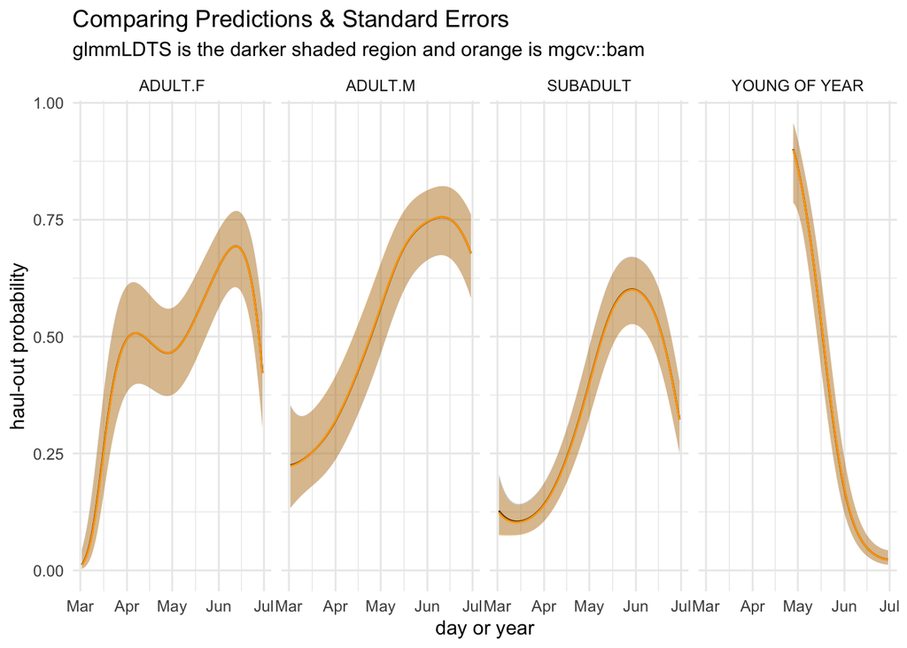

Figure 3: Comparison of predictions and standard errors for the `glmmLDTS` model (darker shade) and the `mgcv::bam()` model (orange). Solar hour was fixed at noon

```r
p3 <- ggplot(plot_df %>% filter(solar_hour == 12), aes(date,ho_prob)) +
  geom_ribbon(aes(ymin=lower95,ymax=upper95), fill = "grey30", alpha = 0.3) +
  geom_line(aes(date,ho_prob)) +
  geom_ribbon(aes(ymin=lower95_bam,ymax=upper95_bam), fill = "orange", alpha = 0.3) +
  geom_line(aes(date, ho_prob_bam), color = "orange") +
  facet_grid(. ~ age_sex) +
  xlab("day or year") +
  ylab("haul-out probability") +
  ggtitle("Comparing Predictions & Standard Errors",
          subtitle = "glmmLDTS is the darker shaded region and orange is mgcv::bam") +
  theme_minimal() +
  theme(legend.position = "none")

p3
```

So, it seems we can adopt `mgcv::bam()` as a quick surrogate for `glmmLDTS` and gain an astonishing decrease in computation time. But, we should probably temper any enthusiasm to rely on `mgcv::bam()` as a complete replacement for `glmmLDTS` in this case before proper comparisons with simulated data and can be done.

Additionally, it is worth considering a possible fairer comparison, in terms of time. This would involve use of the Gaussian process basis functions by including a model formula something like `y ~ x1 + ....xn + s(time, bs = "gp", k = floor(n/2), m = c(2, 3, 1))` to get a reduced rank version of the AR1 model for the residuals (also specifying `method = 'REML'` in the call to `mgcv::bam()`).

## What About a More GAM/BAM-centric Approach

Up to this point, the focus has been on comparing the same model specification (other than the approach for including random effects) between `glmmLDTS` and `mgcv::bam()`. However, a more GAM-like approach to `mgcv::bam()` might rely on a different specification that includes more smooth terms and such.

That might be interesting to explore while we are at it. The `mgcv` pacakge provides a range of options for specifying smooths within the model. For the environmental covariates, we’ll specify a simple cubic spline with a shrinkage component (`bs = "cs"`). For the day of year (`yday`) we’ll specify a cubic spline that varies by age and sex class (`bs = "cr", by=age_sex`) and for solar hour we’ll specify a circular spline (`bs="cc"`). Interactions are handled as tensor product smooths. It wasn’t clear whether the `te()` approach or `ti()` would be best so both are fit and tested with AIC.

```r
spotted_model_data <- spotted_model_data %>%
  mutate(solar_hour = as.integer(solar_hour),
         wind_temp2 = wind*temp2m)


m5ti <- mgcv::bam(
  dry ~ s(speno, bs = "re") +
    s(yday, bs="cr",by=age_sex)+ s(solar_hour, bs="cc")+
    ti(yday, solar_hour, bs=c("cr","cc")) + age_sex +
  s(precip, bs = "cs") + s(temp2m, bs = "cs") +
  s(wind, bs = "cs") + ti(wind, temp2m, bs = "cs") + s(pressure, bs = "cs"),
  data = spotted_model_data,
  family = binomial,
  AR.start = ar1_start,
  rho = lag1,
  discrete = TRUE
)

m5te <- mgcv::bam(
  dry ~ s(speno, bs = "re") +
    te(yday, solar_hour,bs=c("cr","cc"), by=age_sex) + age_sex +
  te(wind, temp2m, bs = "cs") + s(pressure, bs = "cs"),
  data = spotted_model_data,
  family = binomial,
  AR.start = ar1_start,
  rho = lag1,
  discrete = TRUE
)
```

```r
AIC(m5ti, m5te)
```

```
           df       AIC
m5ti 155.3137 -27419.44
m5te 156.9675 -26427.64
```

Ok, looks like the `ti()` approach is favored. Now, let’s do some predictions!

```r
spotted_newdata <- spotted_newdata %>%
  mutate(wind_temp2 = wind*temp2m)

m5_predict <- predict(
      m5ti,
      spotted_newdata,
      type = "link",
      se.fit = TRUE,
      exclude = "s(speno)"
    ) %>%
      as_tibble() %>%
  rename(fit_bam2 = fit, se_bam2 = se.fit) %>%
  mutate(
    logit_bam2_lo95 = fit_bam2 - 1.96 * se_bam2,
    logit_bam2_up95 = fit_bam2 + 1.96 * se_bam2,
    ho_prob_bam2 = plogis(fit_bam2),
    lower95_bam2 = plogis(logit_bam2_lo95),
    upper95_bam2 = plogis(logit_bam2_up95)
  )

spotted_newdata <- spotted_newdata %>%
  bind_cols(m5_predict)
```

And, visualize those predictions similar to our other plots

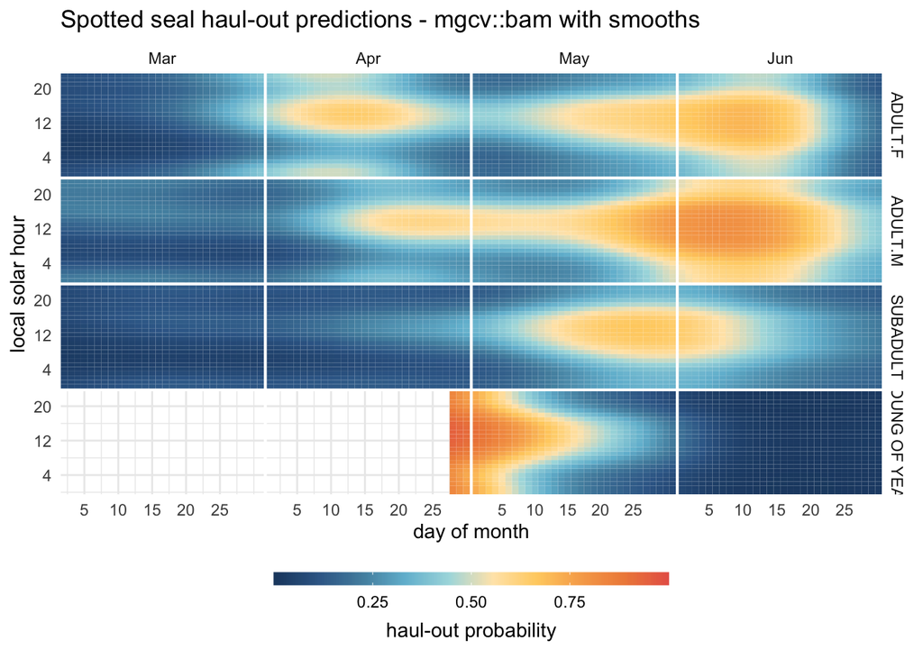

Figure 4: Heat map showing the predicted haul-out probability (response scale) variability over the season and within day from the `mgcv::bam()` with smooths model fit

```r
plot_df <- spotted_newdata %>%
  mutate(date = lubridate::as_date(yday, origin = "2015-01-01"),
         month = lubridate::month(date,label=TRUE),
         day = lubridate::day(date)) %>%
  filter(!month %in% c("Jul","Aug"))

p1 <- ggplot(plot_df, aes(day, solar_hour, fill = ho_prob_bam2)) +
  geom_tile(color = "white", linewidth = 0) +
  scale_fill_gradientn(
    colors = rev(met.brewer("Hiroshige")),
    name = "haul-out probability",
    aesthetics = "fill",
    limits = c(0, 1),
    breaks = c(0.25, 0.50, 0.75),
    guide = guide_colorbar(
      title.position = "bottom",
      barwidth = 15,
      barheight = 0.5,
      title.hjust = 0.5
    )
  )

p1 <- p1 + facet_grid(age_sex~month, scales = "free_x")
p1 <- p1 + scale_x_continuous(breaks = c(5,10,15,20,25)) +
  scale_y_continuous(breaks = c(4,12,20)) +
  coord_cartesian(expand=FALSE)
p1 <- p1 + theme_minimal() +
  theme(panel.spacing = unit(0.1, "lines")) +
  theme(legend.position = "bottom") +
  theme(strip.background = element_rect(colour="white")) +
  theme(axis.ticks=element_blank()) +
  xlab("day of month") + ylab("local solar hour") +
  ggtitle("Spotted seal haul-out predictions - mgcv::bam with smooths")

p1
```

That’s not so bad and, actually, pretty good given the very different approach. I imagine it speaks to the strong signal in the underlying data. An interesting aspect of this result is that we, now, see a period of increased haul-out behavior in adult females that coincides with pupping and nursing. There’s also an increased signal for adult males in that time that would coincide with their courting behavior and hauling out with nursing females. This difference was especially noticeable compared to early model specifications of `glmmLDTS` that only included up to a 3rd order polynomial for day of year. Inclusion of a 4th order polynomial has brought the two models more inline and it’s worth considering whether the gam-centric approach is over-fitting and needs to implement some additional constraints.

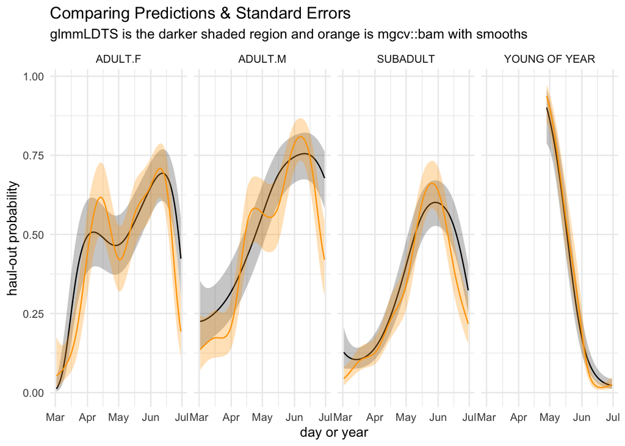

Figure 5: Comparison of predictions and standard errors for the `glmmLDTS` model (darker shade) and the `mgcv::bam()` with smooths model (orange). Solar hour was fixed at noon

```r
p3 <- ggplot(plot_df %>% filter(solar_hour == 12), aes(date,ho_prob)) +
  geom_ribbon(aes(ymin=lower95,ymax=upper95), fill = "grey30", alpha = 0.3) +
  geom_line(aes(date,ho_prob)) +
  geom_ribbon(aes(ymin=lower95_bam2,ymax=upper95_bam2), fill = "orange", alpha = 0.3) +
  geom_line(aes(date, ho_prob_bam2), color = "orange") +
  facet_grid(. ~ age_sex) +
  xlab("day or year") +
  ylab("haul-out probability") +
  ggtitle("Comparing Predictions & Standard Errors",
          subtitle = "glmmLDTS is the darker shaded region and orange is mgcv::bam with smooths") +
  theme_minimal() +
  theme(legend.position = "none")

p3
```

#### Acknowledgments

Special thanks to Debbie Russell, Matt Carter, Peter Boveng, and Jay Ver Hoef for their thoughts, discussions, and encouragement to explore. And, to Paul Conn for his originating work on this analysis.

## References

Hoef, Jay M. Ver, Eryn Blagg, Michael Dumelle, Philip M. Dixon, Dale L. Zimmerman, and Paul Conn. 2023. “Marginal Inference for Hierarchical Generalized Linear Mixed Models with Patterned Covariance Matrices Using the Laplace Approximation.” https://doi.org/10.48550/ARXIV.2305.02978.

Li, Zheyuan, and Simon N. Wood. 2019. “Faster Model Matrix Crossproducts for Large Generalized Linear Models with Discretized Covariates.” *Statistics and Computing* 30 (1): 19–25. https://doi.org/10.1007/s11222-019-09864-2.

London, Josh M., Jay M. Ver Hoef, Steven J. Jeffries, Monique M. Lance, and Peter L. Boveng. 2012. “Haul-Out Behavior of Harbor Seals (Phoca Vitulina) in Hood Canal, Washington.” *PLoS One; San Francisco* 7 (6): e38180. https://doi.org/http://dx.doi.org/10.1371/journal.pone.0038180.

Ver Hoef, Jay M., Josh M. London, and Peter L. Boveng. 2009. “Fast Computing of Some Generalized Linear Mixed Pseudo-Models with Temporal Autocorrelation.” *Computational Statistics* 25 (1): 39–55. https://doi.org/10.1007/s00180-009-0160-1.

Wood, Simon N., Yannig Goude, and Simon Shaw. 2014. “Generalized Additive Models for Large Data Sets.” *Journal of the Royal Statistical Society Series C: Applied Statistics* 64 (1): 139–55. https://doi.org/10.1111/rssc.12068.

Wood, Simon N., Zheyuan Li, Gavin Shaddick, and Nicole H. Augustin. 2017. “Generalized Additive Models for Gigadata: Modeling the U.K. Black Smoke Network Daily Data.” *Journal of the American Statistical Association* 112 (519): 1199–1210. https://doi.org/10.1080/01621459.2016.1195744.